# Integrator configuration

## Scans, fits and other routines

Routines like `scan.*`, `fit.*`, `mc.*` and `mca.*` don't take a `Simulator`, but a *runner*, which describes how each model is simulated. A runner holds the integrator as well as the settings of the steady-state search, so you configure them in one place for every routine.

There is one runner per model builder: `KineticRunner` for the default `Model`, `OdeRunner` for an `OdeModelBuilder` and `EvaluationRunner` for a `SteadyStateModelBuilder`. If no runner is passed, the default runner of the model builder is used.

```python
import numpy as np
import pandas as pd

from mxlpy import KineticRunner, scan

runner = KineticRunner(
    integrator=partial(Scipy, atol=1e-8, rtol=1e-8),
    tolerance=1e-8,  # steady-state tolerance
)

res = scan.steady_state(
    model,
    to_scan=pd.DataFrame({"k1": np.linspace(1, 2, 5)}),
    runner=runner,
)
res.variables
```

| k1 | x | y |
| --- | --- | --- |
| 1.00 | 0.500 | 1.00 |
| 1.25 | 0.625 | 1.25 |
| 1.50 | 0.750 | 1.50 |
| 1.75 | 0.875 | 1.75 |
| 2.00 | 1.000 | 2.00 |

For behaviour the settings don't cover, subclass a runner and override the method you need. The custom runner is then used by every routine you pass it to.

```python
from mxlpy.simulation import Simulation
from mxlpy.types import Result


class LoggingRunner(KineticRunner):
    def steady_state(self, model: mb.KineticModelBuilder) -> Result[Simulation]:
        res = KineticRunner.steady_state(self, model)
        if isinstance(res.value, Exception):
            print(f"Steady state failed: {res.value}")
        return res


res = scan.steady_state(
    model,
    to_scan=pd.DataFrame({"k1": np.linspace(1, 2, 5)}),
    runner=LoggingRunner(),
)
```

## Diffrax

```python
from diffrax import Tsit5

from mxlpy import Diffrax

model = get_linear_chain_2v()

# Use diffrax integrator suite
s = (
    Simulator(model, integrator=Diffrax)  # pyright: ignore[reportArgumentType]
    .simulate(5)
    .get_result()
    .unwrap_or_err()
).variables.plot()


# Explicit solver choice
s = (
    Simulator(model, integrator=partial(Diffrax, solver=Tsit5()))  # pyright: ignore[reportArgumentType]
    .simulate(5)
    .get_result()
    .unwrap_or_err()
).variables.plot()
```

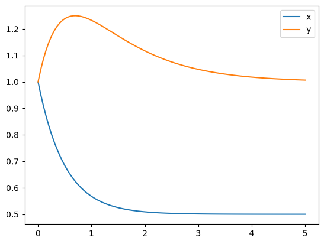

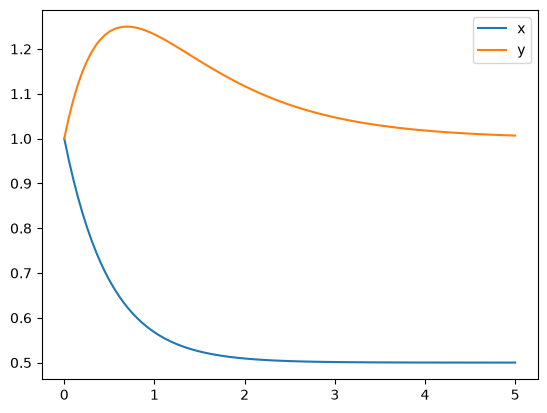

## Native integrator

`Native` compiles a model and runs a C solver outside Python, which makes `simulate` typically 50-200x faster than with `Scipy`. Derived values, reactions and readouts are compiled too, on first read of the results, with the Python path as a fallback for any that can't be. It only works for models that can be represented symbolically, and raises `NativeLoweringError` for any other. It isn't installed by default, and there are two backends:

- `pip install "mxlpy[native]"`: `llvmlite` and a compiled solver. The fastest, needing a wheel for your platform.
- `pip install "mxlpy[native-wasm]"`: `wasmtime` only, more portable, about 1.2-3x slower than `native`.

```
from functools import partial
from mxlpy import Native, Simulator

Simulator(model, integrator=Native).simulate(100)
Simulator(model, integrator=partial(Native, rtol=1e-10, atol=1e-10)).simulate(100)
```

The first simulation of a model compiles it, usually in well under a second. Changing parameters doesn't recompile. Events aren't supported.

The default method is Radau, for stiff models. `partial(Native, method="LSODA")` uses LSODA instead, which switches between non-stiff and stiff methods by itself. It's the same C code `Scipy(method="LSODA")` runs, and on non-stiff models it can be faster than Radau. `method="CVODE_BDF"` (stiff) and `method="CVODE_Adams"` (non-stiff) use [SUNDIALS](https://github.com/LLNL/sundials)' CVODE, the solver `Assimulo` runs, so they give the same results without needing conda.

`partial(Native, reuse_jacobian=True)` (Radau only) reuses Jacobians for longer. That can be about twice as fast on larger stiff models, but error can rise noticeably on some small models, and it's too rough for fits that use finite differences, so keep it off for fitting.